# Tidy Data Homework

### Loading in the data

```r
# Always library
library(readr)
library(here)
library(dplyr)
# Loading in the data
# Setting the WD
setwd(here())

# not downloading it loading in data
kelp <- read_csv("https://github.com/kelpecosystems/observational_data/blob/master/cleaned_data/keen_cover.csv?raw=true")
#Downloading it
kelp_down <- read_csv("data/keen_cover.csv")
```

### Formating

```r
# exploring the data
head(kelp)
```

```
## # A tibble: 6 × 21
##   NETWORK  PI      YEAR MONTH   DAY SITE   TRANS…¹ SP_CODE PERCE…² GROUP DIVIS…³
##   <chr>    <chr>  <dbl> <dbl> <dbl> <chr>  <chr>   <chr>     <dbl> <chr> <chr>
## 1 KEEN ONE Byrnes  2014     7     8 Baker… 1       ANSP       2.5  Inve… Mollus…
## 2 KEEN ONE Byrnes  2014     7     8 Baker… 1       B          7.5  Subs… <NA>
## 3 KEEN ONE Byrnes  2014     7     8 Baker… 1       BA         2.5  Inve… Arthro…
## 4 KEEN ONE Byrnes  2014     7     8 Baker… 1       BL        10    Subs… <NA>
## 5 KEEN ONE Byrnes  2014     7     8 Baker… 1       BM        21.2  Subs… <NA>
## 6 KEEN ONE Byrnes  2014     7     8 Baker… 1       BOSC       1.25 Inve… Chorda…
## # … with 10 more variables: COMMON.DIVISION.NAME <chr>, SIZE <chr>,
## #   COMMON.NAME <chr>, KINGDOM <chr>, PHYLUM <chr>, CLASS <chr>, ORDER <chr>,
## #   FAMILY <chr>, GENUS <chr>, SPECIES <chr>, and abbreviated variable names
## #   ¹TRANSECT, ²PERCENT_COVER, ³DIVISION.FAMILY
```

This data is in a long format because each value in the first column is repeating as it goes down. If it were wide the first column would have unique values as it descended.

### Checking it out

#### How many sites has each PI done

```r
# how many sites has each pi done
kelp |>
  group_by(PI) |>
  summarise(SITE_count = n_distinct(SITE))
```

```
## # A tibble: 6 × 2
##   PI        SITE_count
##   <chr>          <int>
## 1 Byrnes             7
## 2 Dijkstra           1
## 3 Grabowski          1
## 4 Humphries          2
## 5 Hurricane          2
## 6 Pemaquid           1
```

#### How many years of data does each site have?

```r
# How many years of data does each site have?
kelp |>
  group_by(SITE) |>
  summarize(year_count = n_distinct(YEAR)) |>
  ungroup() |>
# in descending order
  arrange(desc(year_count))
```

```
## # A tibble: 14 × 2
##    SITE              year_count
##    <chr>                  <int>
##  1 NE Appledore               7
##  2 NW Appledore               7
##  3 SW Appledore               7
##  4 Fort Weatherill            6
##  5 Baker North                5
##  6 Baker South                5
##  7 Nahant                     5
##  8 Calf Island                4
##  9 Little Brewster            4
## 10 Hurricane Island           3
## 11 King's Beach               3
## 12 Nubble Lighthouse          3
## 13 Pemaquid                   2
## 14 Schoodic                   1
```

#### IYKYK making a fig showing which site sampled when

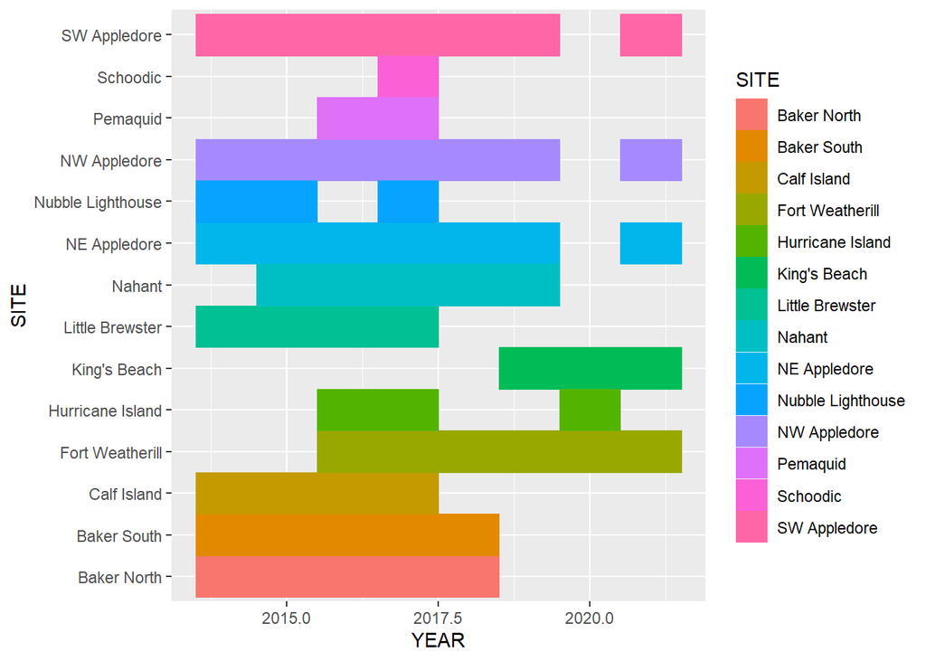

```r
#Impressing by making a figure showing which site was sampled when
library(ggplot2)

ggplot(kelp,
       mapping = aes(x = YEAR,
                     y = SITE,
                     color = SITE,
                     fill = SITE))+
  geom_tile()
```

### Trimming to the right columns

```r
# Trimming to columns YEAR, SITE, TRANSECT, %COVER, FAM, and Species

kelp |>
  select(YEAR, SITE, TRANSECT, PERCENT_COVER, FAMILY, SPECIES)
```

```
## # A tibble: 6,222 × 6
##     YEAR SITE        TRANSECT PERCENT_COVER FAMILY        SPECIES
##    <dbl> <chr>       <chr>            <dbl> <chr>         <chr>
##  1  2014 Baker North 1                 2.5  Anomiidae     Anomia
##  2  2014 Baker North 1                 7.5  <NA>          <NA>
##  3  2014 Baker North 1                 2.5  <NA>          Barnacle
##  4  2014 Baker North 1                10    <NA>          <NA>
##  5  2014 Baker North 1                21.2  <NA>          <NA>
##  6  2014 Baker North 1                 1.25 Styelidae     Botryllus schlosseri
##  7  2014 Baker North 1                 1.25 Styelidae     Botrylloides violaceus
##  8  2014 Baker North 1                18.8  <NA>          <NA>
##  9  2014 Baker North 1                21.2  <NA>          <NA>
## 10  2014 Baker North 1                 7.5  Calyptraeidae Crepidula fornicata
## # … with 6,212 more rows
```

#### Trimming so only the right family is shown and then ditch the rest of the col

```r
# trimming the data so only "Laminariaceae" are shown then ditched the rest of the column
kelp |>
  select(YEAR, SITE, TRANSECT, PERCENT_COVER, FAMILY, SPECIES) |>
  filter(FAMILY == "Laminariaceae") |>
  select(!FAMILY)
```

```
## # A tibble: 345 × 5
##     YEAR SITE        TRANSECT PERCENT_COVER SPECIES
##    <dbl> <chr>       <chr>            <dbl> <chr>
##  1  2014 Baker North 1                 77.5 Saccharina latissima
##  2  2014 Baker North 2                 86.2 Saccharina latissima
##  3  2014 Baker North 3                 31.2 Saccharina latissima
##  4  2014 Baker North 3                  7.5 Saccharina latissima
##  5  2014 Baker North 4                 55   Saccharina latissima
##  6  2014 Baker South 3                 36.2 Saccharina latissima
##  7  2014 Baker South 3                 22.5 Saccharina latissima
##  8  2014 Baker South 4                 32.5 Saccharina latissima
##  9  2014 Baker South 4                 11.2 Saccharina latissima
## 10  2014 Baker South 1                 35   Saccharina latissima
## # … with 335 more rows
```

#### Checking to see if there is only one measurement for each transect each year per species

```r
# Checking to see if there is only one measurement for transect each year per species.
kelp_one_meas <- kelp |>
  select(YEAR, SITE, TRANSECT, PERCENT_COVER, FAMILY, SPECIES) |>
  filter(FAMILY == "Laminariaceae") |>
  select(!FAMILY)|>
  count(SPECIES, TRANSECT, YEAR, SITE)
kelp_one_meas
```

```
## # A tibble: 290 × 5
##    SPECIES            TRANSECT  YEAR SITE                  n
##    <chr>              <chr>    <dbl> <chr>             <int>
##  1 Laminaria digitata 1         2014 Calf Island           1
##  2 Laminaria digitata 1         2014 Little Brewster       1
##  3 Laminaria digitata 1         2014 Nubble Lighthouse     1
##  4 Laminaria digitata 1         2015 Calf Island           1
##  5 Laminaria digitata 1         2015 Little Brewster       1
##  6 Laminaria digitata 1         2016 Fort Weatherill       1
##  7 Laminaria digitata 1         2016 Pemaquid              1
##  8 Laminaria digitata 1         2017 Calf Island           1
##  9 Laminaria digitata 1         2017 Fort Weatherill       1
## 10 Laminaria digitata 1         2017 Little Brewster       1
## # … with 280 more rows
```

#### Summing the cover for each species transect per year

```r
# Summing the cover for each species transect per year
kelp_plot <- kelp |>
  select(YEAR, SITE, TRANSECT, PERCENT_COVER, FAMILY, SPECIES) |>
  filter(FAMILY == "Laminariaceae") |>
  select(!FAMILY)|>
  group_by(SPECIES, TRANSECT, YEAR, SITE)|>
  summarise(sum_cover = sum(PERCENT_COVER))
kelp_plot
```

```
## # A tibble: 290 × 5
## # Groups:   SPECIES, TRANSECT, YEAR [160]
##    SPECIES            TRANSECT  YEAR SITE              sum_cover
##    <chr>              <chr>    <dbl> <chr>                 <dbl>
##  1 Laminaria digitata 1         2014 Calf Island            3.75
##  2 Laminaria digitata 1         2014 Little Brewster        1.25
##  3 Laminaria digitata 1         2014 Nubble Lighthouse      3.75
##  4 Laminaria digitata 1         2015 Calf Island           16.2
##  5 Laminaria digitata 1         2015 Little Brewster        2.5
##  6 Laminaria digitata 1         2016 Fort Weatherill        1.25
##  7 Laminaria digitata 1         2016 Pemaquid              36.2
##  8 Laminaria digitata 1         2017 Calf Island           16.2
##  9 Laminaria digitata 1         2017 Fort Weatherill        2.5
## 10 Laminaria digitata 1         2017 Little Brewster        2.5
## # … with 280 more rows
```

#### Making a plot showing the time of kelps at each site

```
## No summary function supplied, defaulting to `mean_se()`
## No summary function supplied, defaulting to `mean_se()`
## No summary function supplied, defaulting to `mean_se()`
## No summary function supplied, defaulting to `mean_se()`
```

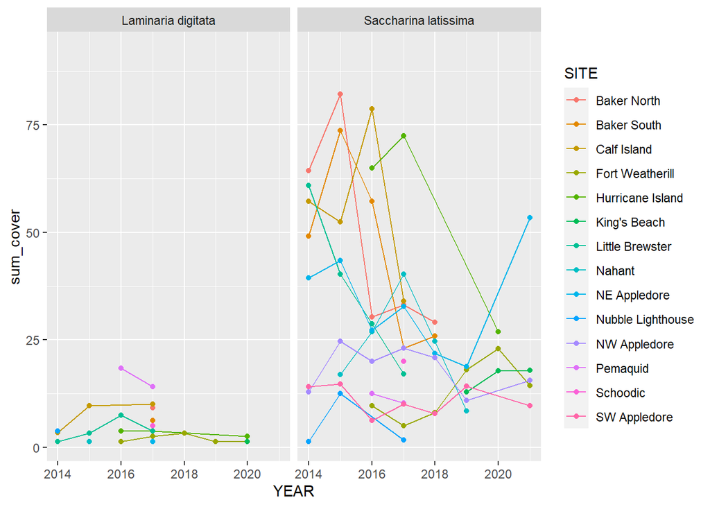

```r
# Making a plot for showing the time of kelps at each site
ggplot(kelp_plot,
       mapping = aes(x = YEAR,
                     y = sum_cover,
                     group = SITE,
                     color = SITE))+
  stat_summary(geom = "line") +
  stat_summary(geom = "point") +
  facet_grid(cols = vars(SPECIES))
```

### Wide Relationships

#### Pivoting wider

```r
library(tidyr)
#pivoting wider
#replacing NAs as 0
kelp_plot_wide <- kelp_plot |>
  pivot_wider(names_from = SPECIES,
              values_from = sum_cover,
              values_fill = 0)
kelp_plot_wide
```

```
## # A tibble: 238 × 5
## # Groups:   TRANSECT, YEAR [135]
##    TRANSECT  YEAR SITE              `Laminaria digitata` `Saccharina latissima`
##    <chr>    <dbl> <chr>                            <dbl>                  <dbl>
##  1 1         2014 Calf Island                       3.75                  57.5
##  2 1         2014 Little Brewster                   1.25                  28.8
##  3 1         2014 Nubble Lighthouse                 3.75                   1.25
##  4 1         2015 Calf Island                      16.2                   63.8
##  5 1         2015 Little Brewster                   2.5                   25
##  6 1         2016 Fort Weatherill                   1.25                   8.75
##  7 1         2016 Pemaquid                         36.2                   21.2
##  8 1         2017 Calf Island                      16.2                   45
##  9 1         2017 Fort Weatherill                   2.5                    1.25
## 10 1         2017 Little Brewster                   2.5                   11.2
## # … with 228 more rows
```

#### Examining if there is a relationship between the two

```
## No summary function supplied, defaulting to `mean_se()`
```

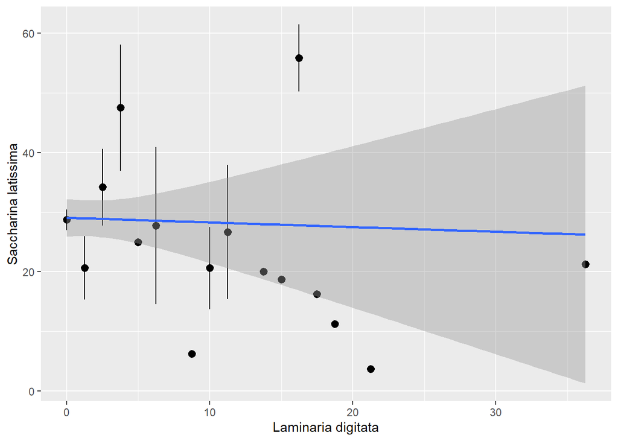

```r
ggplot(kelp_plot_wide,
       mapping = aes(x = `Laminaria digitata`,
                     y = `Saccharina latissima`))+
  stat_summary()+
  stat_smooth(method = "lm")
```

It doesn’t look like there is a relationship between the two species of kelp per transect location year as the stat_smooth line is basically flat. This suggests that the cover of the respective species are not influenced by each other

#### Pivoting back to long

```r
# Pivoting long

kelp_plot_longer <- kelp_plot_wide|>
  pivot_longer(cols = ends_with("a"),
               names_to = "Species",
               values_to = "Cover")
kelp_plot_longer
```

```
## # A tibble: 476 × 5
## # Groups:   TRANSECT, YEAR [135]
##    TRANSECT  YEAR SITE              Species              Cover
##    <chr>    <dbl> <chr>             <chr>                <dbl>
##  1 1         2014 Calf Island       Laminaria digitata    3.75
##  2 1         2014 Calf Island       Saccharina latissima 57.5
##  3 1         2014 Little Brewster   Laminaria digitata    1.25
##  4 1         2014 Little Brewster   Saccharina latissima 28.8
##  5 1         2014 Nubble Lighthouse Laminaria digitata    3.75
##  6 1         2014 Nubble Lighthouse Saccharina latissima  1.25
##  7 1         2015 Calf Island       Laminaria digitata   16.2
##  8 1         2015 Calf Island       Saccharina latissima 63.8
##  9 1         2015 Little Brewster   Laminaria digitata    2.5
## 10 1         2015 Little Brewster   Saccharina latissima 25
## # … with 466 more rows
```

```
## No summary function supplied, defaulting to `mean_se()`
## No summary function supplied, defaulting to `mean_se()`
## No summary function supplied, defaulting to `mean_se()`
## No summary function supplied, defaulting to `mean_se()`
```

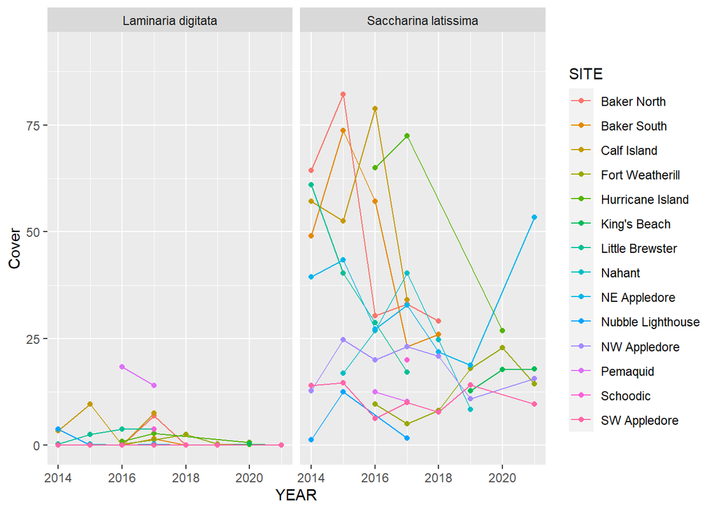

```r
ggplot(kelp_plot_longer,
        mapping = aes(x = YEAR,
                     y = Cover,
                     group = SITE,
                     color = SITE))+
  stat_summary(geom = "line") +
  stat_summary(geom = "point") +
  facet_grid(cols = vars(Species))
```

It looks only slightly different in that the points align to 0 instead of not being plotted on the Laminaria species plot. It appears to be more complete but not really more informative. It also could be misleading as the NA suggest that it wasn’t charted but not actually a true 0.

Meta 1: I felt okay working with it in the first part of the homework like dropping columns and finding out things about the data, however because I unfamiliar with what the data actually was it was hard for me to visualize what was acutally being collected (like what a transect was).

Meta 2: Split-Apply-Combine is something that I may have completed in the past without actually knowing what it was.

Meta 3: I typically make data sets that are long because each animal is sepearated out instead of their group assignments. However when plotting I desire to collapse the groups having the data represent groups. Advice to future me would be to think of data in these seperate formats to aid in the proper processing of them to make sure that my plot tells the right story.

Meta 4: This took me a while because some of the questions were hard to understand what the goal was. This took me perhaps 5-7 hours split up over the week.

Meta 5: I give this a strong in the end but perhaps while I was doing it and while I was learning it I would say a sufficient. It was difficult for me to understand the goal of some of the questions. So in that regard it was hard to picture the end and that informs the steps.